# Hyperparameter Tuning with XGBoost

Kaz Sakamoto

```r
library(caret)
library(dplyr)
library(ggplot2)
## here we are going to find the root_file
root <- rprojroot::find_rstudio_root_file()
## we are going to set the data file path here
dataDir <- file.path(root, 'Data')
```

## Boosting vs Bagging

We have actually already been working with Bagging already through the Random Forest algorithm. Unline single learner systems like a decision tree, Random Forest and XGBoost have many learners.

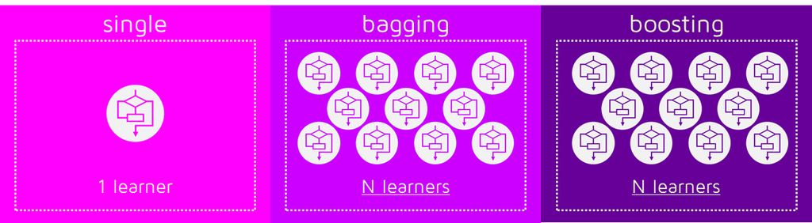

The way they sample is a little different though. A single learner will use all it’s data to create a tree, while bagging could use random sampling with replacement which means that for every learner being created, only a sample of the total data is used and the same data point could be used. Boosting on the otherhand will have weighted observations and some of them will take part in the samples more frequently.

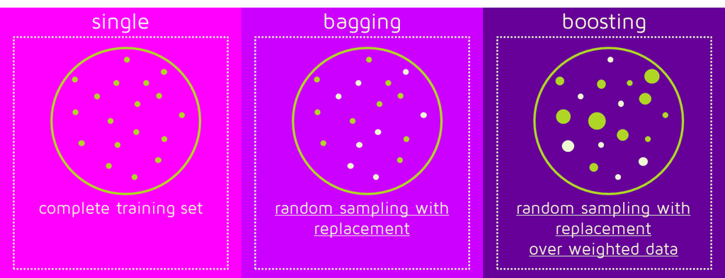

The last point about the weights are important becasue this is the main differentiator between bagging and boosting. Bagging create learners in parallel or all at once, while boosting creates them sequentially. Therefore it is a btit slower but it can continually learn from the previous iteration to improve upon the model. Harder to classify or predict observations will receive greater weights.

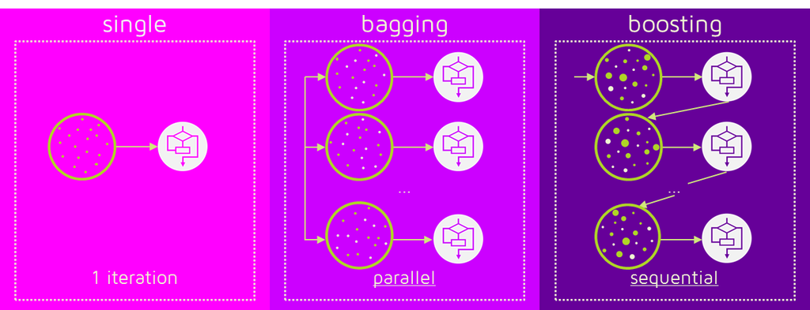

**Which is the best, Bagging or Boosting?**

There’s not an outright winner; it depends on the data, the simulation and the circumstances. Bagging and Boosting decrease the variance of your single estimate as they combine several estimates from different models. So the result may be a model with higher stability.

If the problem is that the single model gets a very low performance, Bagging will rarely get a better bias. However, Boosting could generate a combined model with lower errors as it optimises the advantages and reduces pitfalls of the single model.

By contrast, if the difficulty of the single model is over-fitting, then Bagging is the best option. Boosting for its part doesn’t help to avoid over-fitting; in fact, this technique is faced with this problem itself. For this reason, Bagging is effective more often than Boosting. [source](https://www.kdnuggets.com/2017/11/difference-bagging-boosting.html)

## Caret

Caret stands for Classification And REgression Training. Caret is a powerful package since it can preprocess and split data. We are going to explore how we can use this package for tuning parameters based on some measures of model performance.

## Training

For the sake of training, we are going to be using the formula interface for putting in our response and predictor variables. This will change them into a matrix. XGBoost requires all numeric inputs to all categorical variables must be convereted into numeric such as One Hot Encoding as a tool.

## Training Controls

- `method` is the type of resampling technique should be applied. Common ones are ‘boot’ for bootstrap, or ‘reapeatedcv’ for repeated cross-validation. look out for extra arguments that need to be filled out.
- `summaryFunction` is the way in which the performance of the model is judged. Some of them can include Area Under the Curve (AUC) for classification or root meas squared erro (RMSE) for regression.
- `allowParallel` will turn parllel processing on of off.

## Search Grid

The main reason Caret is being introduced is the ability to select optimal model parameters through a grid search. In the case of XGBoost, this could be the maximum tree depth and/or the amount of shirnkage. If you recall from glmnet (elasticnet) you could find the best lambda value of the penalty or the alpha, the best mix between ridge and lasso.

The search grid is included as a data.frame and passed into the `train` function’s tuneGrid parameter. Each parameter should be in a column and each row the set of parameters.

## Example

Let’s load in the data set from last week. I’m going to split the dataset into train and test.

```r
mnPluto <- readr::read_csv(file.path(dataDir, "MN_Pluto.csv"))

singleZip <- mnPluto %>% count(zipcode) %>% filter(n < 10) %>% pull(zipcode)

mnPluto <- mnPluto %>% mutate(assesstotZ = scale(assesstot)) %>%
    filter(assesstotZ < 3 & assesstotZ > -3 ) %>%
    mutate(numbldgs =as.numeric(numbldgs),
          bldgarea = as.numeric(bldgarea)) %>%
    dplyr::select(assesstot, zipcode, exempttot,
                        numbldgs, lotarea, bldgarea, comarea, resarea,
                        officearea, retailarea, garagearea, strgearea, numfloors,
                        landuse, builtfar, yearbuilt, bbl) %>%
    mutate(landuse = as.character(landuse),
           zipcode = as.character(zipcode))%>%
    filter(complete.cases(.)) %>%
    filter(!zipcode %in% singleZip)

set.seed(1234)
trainMN <- mnPluto %>% group_by(zipcode) %>%
    dplyr::sample_frac(size = .75,replace = FALSE) %>%
    ungroup()
testMN <- mnPluto %>% filter(!bbl %in% trainMN$bbl)
```

Using the `useful` package lets create the train and test matrix and the labels for validation.

```r
trainMNX <- useful::build.x(assesstot ~  zipcode  + exempttot  +
                        numbldgs + lotarea + bldgarea + comarea + resarea +
                        officearea + retailarea + garagearea + strgearea + numfloors +
                        landuse  + builtfar + yearbuilt - 1, trainMN, contrasts = FALSE)
dim(trainMNX)
```

```
## [1] 29494    70
```

```r
trainMNY <- useful::build.y(assesstot ~  zipcode  + exempttot  +
                        numbldgs + lotarea + bldgarea + comarea + resarea +
                        officearea + retailarea + garagearea + strgearea + numfloors +
                        landuse  + builtfar + yearbuilt - 1, trainMN)
head(trainMNY)
```

```
## [1]   624150   766268 57415050 10589400  1095300 62991900
```

```r
testMNX <- useful::build.x(assesstot ~  zipcode  + exempttot  +
                        numbldgs + lotarea + bldgarea + comarea + resarea +
                        officearea + retailarea + garagearea + strgearea + numfloors +
                        landuse  + builtfar + yearbuilt - 1, testMN, contrasts = FALSE)
dim(testMNX)
```

```
## [1] 9831   70
```

```r
testMNY <- useful::build.y(assesstot ~  zipcode  + exempttot +
                        numbldgs + lotarea + bldgarea + comarea + resarea +
                        officearea + retailarea + garagearea + strgearea + numfloors +
                        landuse  + builtfar + yearbuilt - 1, testMN)
head(testMNY)
```

```
## [1]  677666   40084 4643789  251365  236413  446154
```

Below is the default training search grid and training controls.

```r
grid_default <- expand.grid(
  nrounds = 100,
  max_depth = 6,
  eta = 0.3,
  gamma = 0,
  colsample_bytree = 1,
  min_child_weight = 1,
  subsample = 1
)

train_control <- caret::trainControl(
  method = "none",
  verboseIter = FALSE, # no training log
  allowParallel = TRUE
)

xgb_base <- caret::train(
  x = trainMNX,
  y = trainMNY,
  trControl = train_control,
  tuneGrid = grid_default,
  method = "xgbTree",
  verbose = TRUE,
  nthreads = 4
)
```

We can use the default model to make some predictions and create a RMSE value.

```r
basePred <- predict(xgb_base,testMNX)
baseRMSE <- caret::RMSE(basePred, testMNY)
baseRMSE
```

```
## [1] 2975557
```

Now let’s tune some of our parameters and create a new model.

- **eta:**

Learning (or shrinkage) parameter. It controls how much information from a new tree will be used in the Boosting. This parameter must be bigger than 0 and limited to 1. If it is close to zero we will use only a small piece of information from each new tree. If we set eta to 1 we will use all information from the new tree. Big values of eta result in a faster convergence and more over-fitting problems. Small values may need to many trees to converge.

- **colsample_bylevel:**

Just like Random Forests, some times it is good to look only at a few variables to grow each new node in a tree. If we look at all variables the algorithm needs less trees to converge, but looking at, for example, 2/3 of the variables may result in models more robust to over-fitting. There is a similar parameter called colsample_bytree that re-sample the variables in each new tree instead of each new node.

- **max_depth:**

Controls the maximum depth of the trees. Deeper trees have more terminal nodes and fit more data. Convergence also requires less trees if we grow them deep. However, if the trees are to deep we will be using a lot of information from the first trees and the final trees of the algorithm will have less importance on the loss function. The Boosting benefits from using information from many trees. Therefore it is intuitive that huge trees are not desirable. Smaller trees also grow faster and because the Boosting grow new trees in a pseudo-residual and we do not require any amazing adjustment for an individual tree.

```r
tune_grid <- expand.grid(
  nrounds = 100,
  eta = c(0.01, 0.1, 0.3),
  max_depth = c(2, 3, 5, 10),
  gamma = c(0),
  colsample_bytree = 1,
  min_child_weight = 1,
  subsample = 1
)

tune_control <- caret::trainControl(
  method = "cv", # cross-validation
  number = 3, # with n folds
  verboseIter = FALSE, # no training log
  allowParallel = TRUE #
)

xgb_tune <- caret::train(
  x = trainMNX,
  y = trainMNY,
  trControl = tune_control,
  tuneGrid = tune_grid,
  method = "xgbTree",
  verbose = TRUE,
  nthreads = 4
)
```

We can plot out the different etas used and compare the max depths.

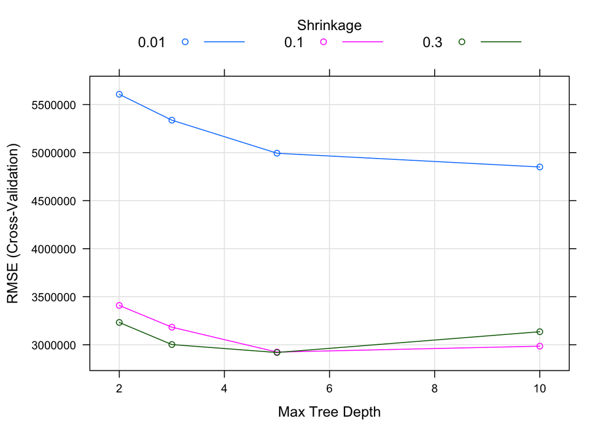

```r
plot(xgb_tune)
```

We can compute the RMSE for the tuned model.

```r
tunePred <- predict(xgb_tune,testMNX)
tuneRMSE <- caret::RMSE(tunePred, testMNY)
tuneRMSE
```

```
## [1] 2961175
```

Let’s create a histogram of the residuals.

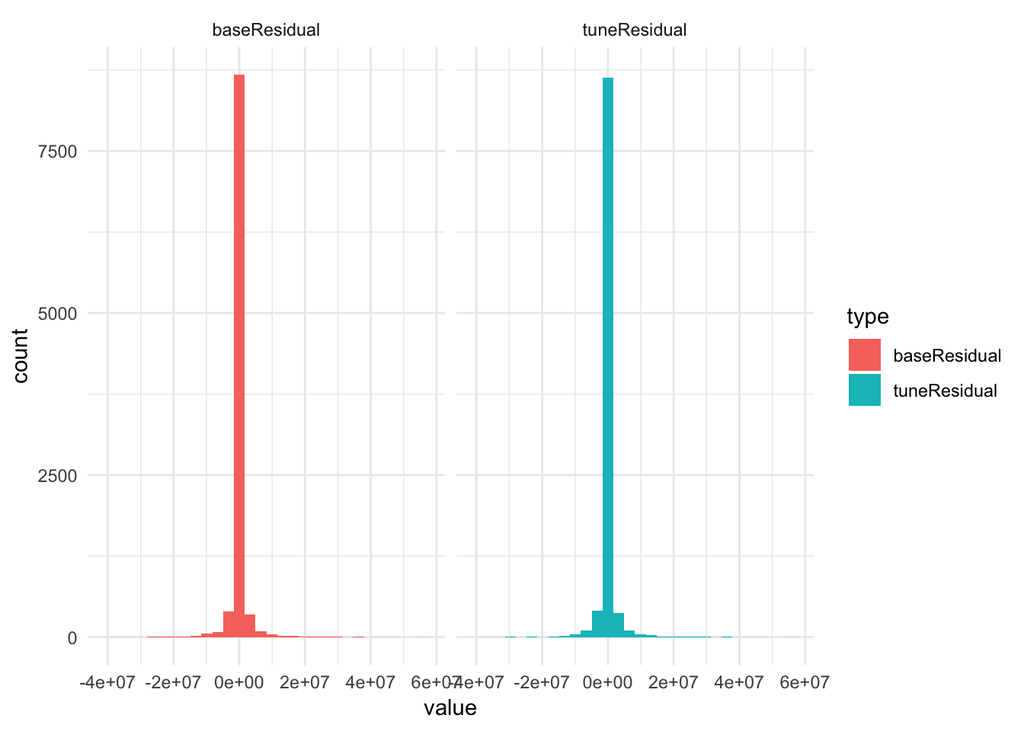

```r
data.frame(baseResidual = testMNY-basePred,
           tuneResidual = testMNY-tunePred,
           row = 1:length(basePred)) %>%
    tidyr::gather(type, value, -row) %>%
    ggplot(aes(x =value, fill = type)) +
    geom_histogram() + facet_wrap(~type) +
    theme_minimal()
```

Let’s create a line chart of the residuals.

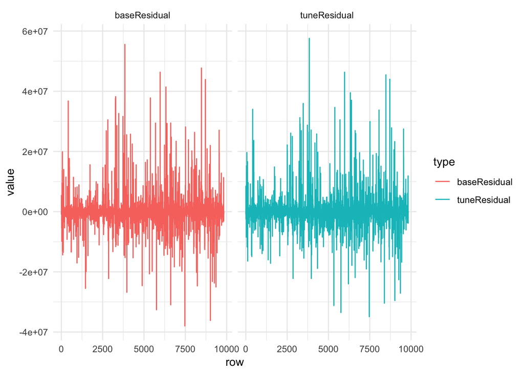

```r
data.frame(baseResidual = testMNY-basePred,
           tuneResidual = testMNY-tunePred,
           row = 1:length(basePred)) %>%
    tidyr::gather(type, value, -row) %>%
    ggplot(aes(x = row, y =value, color = type)) +
    geom_line() + facet_wrap(~type) +
    theme_minimal()
```